# Гречишкин Денис ПМ-31:

Далее возьмем выборки объёма 500 и 1000

```
РАЗМЕР ВЫБОРКИ - 500

k1 =  23
nk = [4.49173731 3.50143302 2.36965669 1.83913654 1.13177633 1.20251235
 0.74272822 0.60125618 0.31831209 0.45978413 0.17684005 0.21220806
 0.14147204 0.07073602 0.07073602 0.14147204 0.03536801 0.03536801
 0.03536801 0.03536801 0.         0.         0.07073602]
zk = [5.23502884e-04 5.70717786e-02 1.13620054e-01 1.70168330e-01
 2.26716606e-01 2.83264882e-01 3.39813157e-01 3.96361433e-01
 4.52909709e-01 5.09457984e-01 5.66006260e-01 6.22554536e-01
 6.79102812e-01 7.35651087e-01 7.92199363e-01 8.48747639e-01
 9.05295915e-01 9.61844190e-01 1.01839247e+00 1.07494074e+00
 1.13148902e+00 1.18803729e+00 1.24458557e+00]
Максимальное отклонение от плотности, число интервалов = 23:     0.49519223001601276

k2 =  16
nk = [4.50250149 2.46038333 1.82068366 1.20558783 0.76271883 0.46747283
 0.3690575  0.17222683 0.17222683 0.09841533 0.12301917 0.02460383
 0.04920767 0.02460383 0.         0.04920767]
zk = [5.23502884e-04 8.18116492e-02 1.63099796e-01 2.44387942e-01
 3.25676088e-01 4.06964235e-01 4.88252381e-01 5.69540527e-01
 6.50828674e-01 7.32116820e-01 8.13404967e-01 8.94693113e-01
 9.75981259e-01 1.05726941e+00 1.13855755e+00 1.21984570e+00]
Максимальное отклонение от плотности, число интервалов = 16:     0.8609943711829593

k3 =  10
nk = [3.84434895 1.8145327  0.93802114 0.47669927 0.27679312 0.15377396
 0.09226437 0.03075479 0.03075479 0.03075479]
zk = [5.23502884e-04 1.30584537e-01 2.60645571e-01 3.90706605e-01
 5.20767640e-01 6.50828674e-01 7.80889708e-01 9.10950742e-01
 1.04101178e+00 1.17107281e+00]
Максимальное отклонение от плотности, число интервалов = 10:     1.1425805929409534

k4 =  15
nk = [4.33642561 2.53727031 1.61462656 1.1071725  0.62278453 0.39212359
 0.34599141 0.16146266 0.13839656 0.11533047 0.04613219 0.02306609
 0.04613219 0.         0.04613219]
zk = [5.23502884e-04 8.72308590e-02 1.73938215e-01 2.60645571e-01
 3.47352927e-01 4.34060283e-01 5.20767640e-01 6.07474996e-01
 6.94182352e-01 7.80889708e-01 8.67597064e-01 9.54304420e-01
 1.04101178e+00 1.12771913e+00 1.21442649e+00]
Максимальное отклонение от плотности, число интервалов = 15:     0.6953195126581608

k5 =  24
nk = [4.42868999 3.61676349 2.39887374 1.95600474 1.29170125 1.29170125
 0.70120925 0.6643035  0.47977475 0.33215175 0.33215175 0.147623
 0.2214345  0.147623   0.03690575 0.147623   0.03690575 0.03690575
 0.03690575 0.0738115  0.         0.         0.         0.0738115 ]
zk = [5.23502884e-04 5.47156005e-02 1.08907698e-01 1.63099796e-01
 2.17291893e-01 2.71483991e-01 3.25676088e-01 3.79868186e-01
 4.34060283e-01 4.88252381e-01 5.42444479e-01 5.96636576e-01
 6.50828674e-01 7.05020771e-01 7.59212869e-01 8.13404967e-01
 8.67597064e-01 9.21789162e-01 9.75981259e-01 1.03017336e+00
 1.08436545e+00 1.13855755e+00 1.19274965e+00 1.24694175e+00]
Максимальное отклонение от плотности, число интервалов = 24:     0.5582395527711741
```

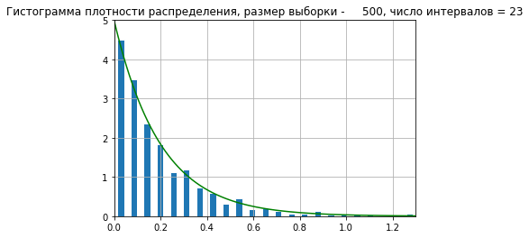

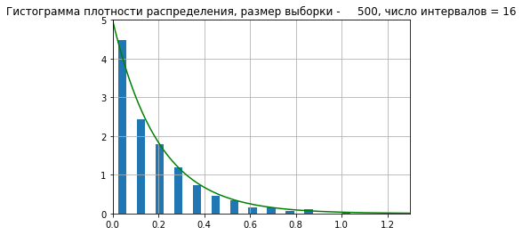

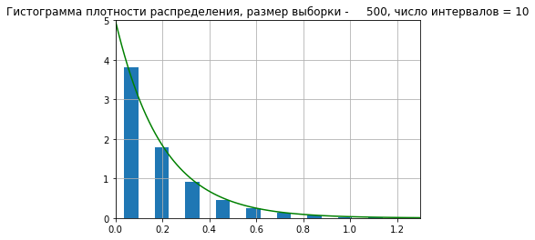

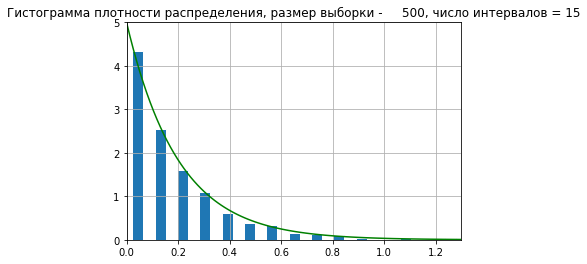

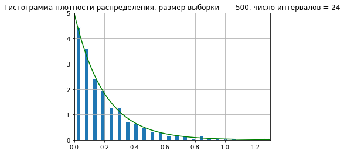

```python
L = 5
Size = 500
print(f'РАЗМЕР ВЫБОРКИ - {Size}\n')
X = np.random.exponential(scale = 1/L, size = Size)
rules = ['sqrt', 'rice', 'sturges', 'scott', 'fd']

for i in range(len(rules)):
    #строим гистограмму и находим число интервалов
    plt.figure()
    nk_zk = plt.hist(X, bins = rules[i], edgecolor = 'white', \
                     density = True, rwidth = 0.5)
    nk = np.array(nk_zk[0])
    zk = np.array(nk_zk[1])
    zk = zk[:len(nk)]
    amt = np.size(zk)

    plt.title(f'Гистограмма плотности распределения, размер выборки - \
    {Size}, число интервалов = {amt}')
    plt.grid(True)
    plt.axis([0, 1.3, 0, 5])

    print(f'k{i + 1} = ', amt)
    print('nk =', nk)
    print('zk =', zk)

    #строим график теоретической плотности распределения
    x = np.linspace(0, 1.3, 100)
    f_x = L*np.exp(-L*x)
    plt.plot(x, f_x, color = 'g')

    #находим отклонения
    otkls = []
    for j in range(len(zk)):
        otkls.append(np.abs(nk[j] - L*np.exp(-L*zk[j])))
    max_otkl = max(otkls)
    print(f'Максимальное отклонение от плотности, число интервалов = {amt}:\
    ', max_otkl, '\n')
```

В случае с выборкой объёма 500 правила по рейтингу точности можно расставить следующим образом:

1. Правило квадратного корня
2. Правило Фридмана – Диакониса
3. Правило Скотта
4. Правило Райса
5. Правило Стреджесса

```
РАЗМЕР ВЫБОРКИ - 1000

k1 =  32
nk = [4.60737572 3.22020883 3.24497967 2.50185455 1.90735446 1.65964609
 1.16422935 1.31285437 1.065146   0.64404177 0.6688126  0.61927093
 0.54495842 0.29725005 0.24770837 0.14862502 0.22293753 0.17339586
 0.07431251 0.12385419 0.04954167 0.02477084 0.04954167 0.02477084
 0.09908335 0.         0.         0.02477084 0.02477084 0.
 0.         0.02477084]
zk = [2.79831308e-05 4.03980357e-02 8.07680883e-02 1.21138141e-01
 1.61508194e-01 2.01878246e-01 2.42248299e-01 2.82618351e-01
 3.22988404e-01 3.63358457e-01 4.03728509e-01 4.44098562e-01
 4.84468614e-01 5.24838667e-01 5.65208720e-01 6.05578772e-01
 6.45948825e-01 6.86318877e-01 7.26688930e-01 7.67058983e-01
 8.07429035e-01 8.47799088e-01 8.88169140e-01 9.28539193e-01
 9.68909246e-01 1.00927930e+00 1.04964935e+00 1.09001940e+00
 1.13038946e+00 1.17075951e+00 1.21112956e+00 1.25149961e+00]
Максимальное отклонение от плотности, число интервалов =     32:  0.8653059314702904

k2 =  20
nk = [4.14911523 3.0653911  2.26033889 1.64106796 1.14565122 0.91342462
 0.60378916 0.65023448 0.26319015 0.21674483 0.17029951 0.12385419
 0.09289064 0.04644532 0.03096355 0.06192709 0.         0.03096355
 0.         0.01548177]
zk = [2.79831308e-05 6.46200673e-02 1.29212151e-01 1.93804236e-01
 2.58396320e-01 3.22988404e-01 3.87580488e-01 4.52172572e-01
 5.16764657e-01 5.81356741e-01 6.45948825e-01 7.10540909e-01
 7.75132993e-01 8.39725077e-01 9.04317162e-01 9.68909246e-01
 1.03350133e+00 1.09809341e+00 1.16268550e+00 1.22727758e+00]
Максимальное отклонение от плотности, число интервалов =     20:  0.850185243334856

k3 =  11
nk = [3.73807415 2.06062402 1.18358156 0.73228787 0.37465891 0.20435941
 0.11920965 0.0340599  0.04257488 0.01702995 0.00851498]
zk = [2.79831308e-05 1.17468136e-01 2.34908289e-01 3.52348442e-01
 4.69788595e-01 5.87228748e-01 7.04668901e-01 8.22109054e-01
 9.39549207e-01 1.05698936e+00 1.17442951e+00]
Максимальное отклонение от плотности, число интервалов =     11:  1.2612263227590796

k4 =  20
```

[output cut: 11 more lines]

```
k5 =  29
nk = [4.62440567 3.07545425 3.03055711 2.26730569 1.90812855 1.39181141
 1.18977427 0.96528856 0.83059713 0.65100856 0.56121428 0.56121428
 0.24693428 0.22448571 0.22448571 0.13469143 0.11224286 0.15714
 0.04489714 0.02244857 0.04489714 0.06734571 0.04489714 0.
 0.         0.04489714 0.         0.         0.02244857]
zk = [2.79831308e-05 4.45742481e-02 8.91205130e-02 1.33666778e-01
 1.78213043e-01 2.22759308e-01 2.67305573e-01 3.11851838e-01
 3.56398103e-01 4.00944368e-01 4.45490633e-01 4.90036898e-01
 5.34583162e-01 5.79129427e-01 6.23675692e-01 6.68221957e-01
 7.12768222e-01 7.57314487e-01 8.01860752e-01 8.46407017e-01
 8.90953282e-01 9.35499547e-01 9.80045812e-01 1.02459208e+00
 1.06913834e+00 1.11368461e+00 1.15823087e+00 1.20277714e+00
 1.24732340e+00]
Максимальное отклонение от плотности, число интервалов =     29:  0.9256351386522907
```

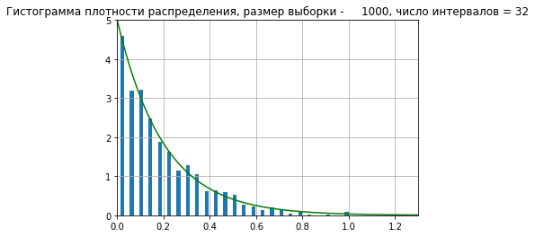

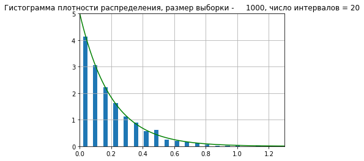

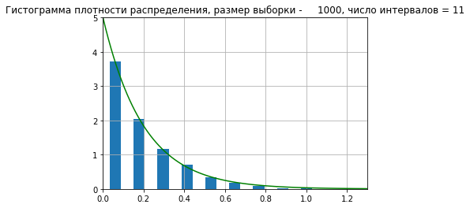

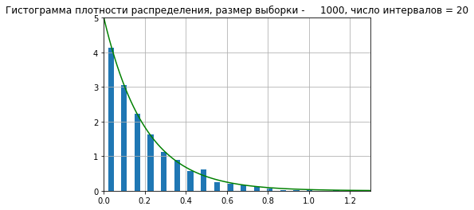

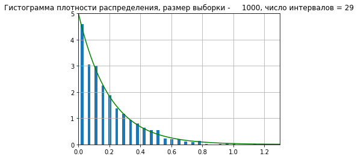

```python
L = 5
Size = 1000
print(f'РАЗМЕР ВЫБОРКИ - {Size}\n')
X = np.random.exponential(scale = 1/L, size = Size)
rules = ['sqrt', 'rice', 'sturges', 'scott', 'fd']

for i in range(len(rules)):
    #строим гистограмму и находим число интервалов
    plt.figure()
    nk_zk = plt.hist(X, bins = rules[i], edgecolor = 'white', \
                     density = True, rwidth = 0.5)
    nk = np.array(nk_zk[0])
    zk = np.array(nk_zk[1])
    zk = zk[:len(nk)]
    amt = np.size(zk)

    plt.title(f'Гистограмма плотности распределения, размер выборки - \
    {Size}, число интервалов = {amt}')
    plt.grid(True)
    plt.axis([0, 1.3, 0, 5])

    print(f'k{i + 1} = ', amt)
    print('nk =', nk)
    print('zk =', zk)

    #строим график теоретической плотности распределения
    x = np.linspace(0, 1.3, 100)
    f_x = L*np.exp(-L*x)
    plt.plot(x, f_x, color = 'g')

    #находим отклонения
    otkls = []
    for j in range(len(zk)):
        otkls.append(np.abs(nk[j] - L*np.exp(-L*zk[j])))
    max_otkl = max(otkls)
    print(f'Максимальное отклонение от плотности, число интервалов = \
    {amt}: ', max_otkl, '\n')
```

В случае с выборкой объёма 1000 правила по рейтингу точности можно расставить следующим образом:

1. Правило Скотта, правило Райса
2. Правило квадратного корня
3. Правило Фридмана-Диакониса
4. Правило Стреджесса

Можно сделать вывод, что выбор способа подсчёта выборки зависит от содержащихся в ней и от её размера. То есть сказать что рейтинг устойчив - нельзя.

$\newline$

## Задание 4, вариант 7:

Пусть $X_i$ – случайные величины, распределенная по тому же закону, что и случайная величина X из вашего варианта, причем эти величины независимы. Постройте гистограммы по выборке объема 200 для следующих случайных величин. 1) Для случайной величины $X$. 2) Для случайной величины $\frac{1}{5} \sum_{i = 1}^{5} X_i$. 3) Для случайной величины $\frac{1}{50} \sum_{i = 1}^{50} X_i$. 4) Для случайной величины $\frac{1}{500} \sum_{i = 1}^{500} X_i$. $\newline$ К какому теоретическому распределению приближается случайная величина из п. 4)? Проиллюстрируйте ответ на этот вопрос, наложив на гистограмму график плотности этого распределения.$\newline$ Вариант 7: X имеет распределение Фишера с параметрами 6, 5

## Решение: составим выборки для каждой из случайных величин c помощью функции np.random.f() и построим гистограммы с помощью функции plt.hist(). $\newline$

Разберем последний пункт задания. Т.к случайные величины $X_i$ независимы, одинаково распределены и имеют конечные m и $\sigma$, то по центральной предельной теореме получаем: $$\frac{1}{500} \sum_{i = 1}^{500} X_i \rightarrow N(m; \frac{\sigma}{\sqrt{500}})$$ Для распределения Фишера $F(d_1, d_2)$ с параметрами $d_1 = 6$ и $d_2 = 5$ найдем мат ожидание и дисперсию: $$M_X = \frac{d_2}{d_2 - 2} = \frac{5}{5 - 2} = \frac{5}{3}$$ $$D_X = \frac{2d_2^2(d_1 + d_2 - 2)}{d_1 \cdot (d_2 - 2)^2 \cdot (d_2 - 4)} = \frac{2\cdot 5^2(6 + 5 - 2)}{6 \cdot (5 - 2)^2 \cdot (5 - 4)} = \frac{25}{3}$$ Т.е получаем что по центральной предельной теореме $$\frac{1}{500} \sum_{i = 1}^{500} X_i \rightarrow N(\frac{5}{3}; \sqrt{\frac{25}{3 \cdot 500}})$$ Проверим это, построив на последнем графике функцию плотности нормального распределения с этими параметрами c с помощью функции R.pdf() (R - распределение)

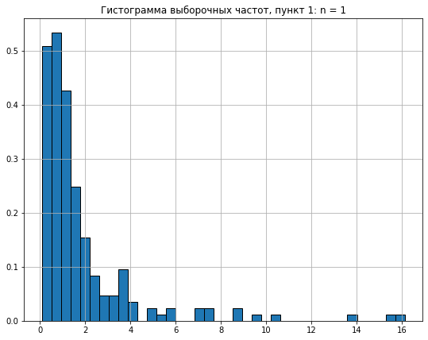

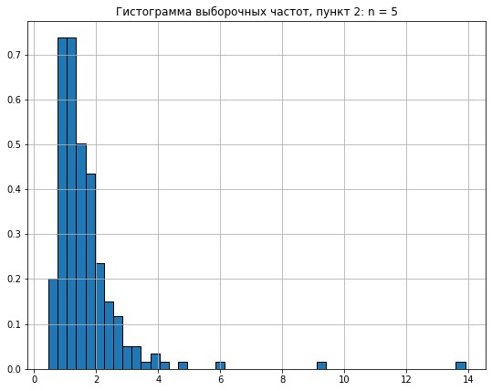

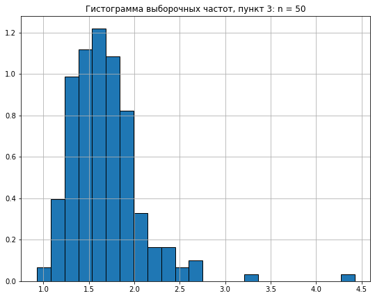

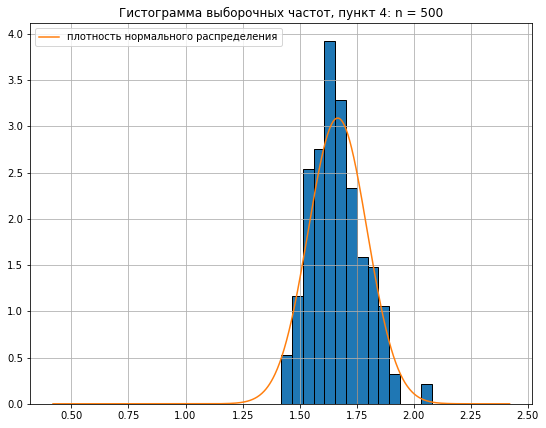

```python
d1 = 6
d2 = 5
size = 200
ns = [1, 5, 50, 500]
for i in range(len(ns)):
    X_k = [0*k for k in range(size)]
    #строим выборку для случайных величин
    for j in range(ns[i]):
        X = np.random.f(d1, d2, size)
        X_k = np.add(X_k, X)
    X_k = X_k / ns[i]
    #строим гистограммы
    plt.figure(figsize = (9, 7))
    plt.hist(X_k, bins = 'auto', edgecolor = 'black', density = True)
    plt.title(f'Гистограмма выборочных частот, пункт {i + 1}: n = {ns[i]}')
    plt.grid(True)

    #для последнего случая строим график плотности нормального распределения
    if (ns[i] == 500):
        x_pl = np.linspace(min(X_k) - 1, min(X_k) + 1, 1000)
        f_X_pl = (sts.norm(5/3, np.sqrt(25/(3*500)))).pdf(x_pl)
        plt.plot(x_pl, f_X_pl, \
                 label = 'плотность нормального распределения')
        plt.legend()
```